# France 2027 Presidential Election Analysis

It’s all Macron’s fault

Political Analysis Project

April 01, 2026

# 1 The French Two-Round Presidential System

France elects its president under a two-round (*scrutin à deux tours*) system enshrined in Article 7 of the 1958 Constitution. It is one of the most consequential features of the Fifth Republic and fundamentally shapes how parties, candidates, and voters behave.

```r
runoff_rules <- tibble(
  Round   = c("First Round", "First Round", "Second Round", "Second Round", "Second Round"),
  Rule    = c(
    "All qualifying candidates compete. To win outright, a candidate must receive an absolute majority of votes cast — over 50%, including blank and void ballots.",
    "In practice, no candidate has won outright in the first round since the system was introduced. The top two candidates by vote share advance to the second round.",
    "Held two weeks after the first round. Only the two finalists compete.",
    "The candidate who receives the most votes wins — a simple majority suffices in round two.",
    "Crucially, voters who backed eliminated first-round candidates must choose whether to transfer their vote, abstain, or cast a blank/void ballot. This transfer dynamic is the central strategic variable."
  ),
  Strategic_implication = c(
    "Candidates try to consolidate their own bloc in round one. Fragmentation helps: niche candidates can stay in to signal strength before endorsing a finalist.",
    "Finishing first in round one provides momentum but does not guarantee the presidency. Le Pen topped the first round in both 2017 and 2022 — and lost the second round heavily each time.",
    "The two-candidate format eliminates triangulation. Voters must choose between the two, or not vote.",
    "A second-round win is decisive regardless of first-round margin. Macron won the 2022 second round with 58.5% having taken 27.8% in the first.",
    "The Republican Front (front républicain): the tradition of French voters uniting across party lines to block the far right in the second round. It held in 2002 (Chirac 82% vs Jean-Marie Le Pen), 2017 (Macron 66% vs Marine Le Pen), and 2022 (Macron 58.5% vs Le Pen). Whether it holds in 2027 is the central question of this analysis."
  )
)

runoff_rules %>%
  kable(
    caption = "The French Two-Round Presidential System: Rules and Strategic Implications",
    col.names = c("Stage", "Rule", "Strategic Implication"),
    align = "lll"
  ) %>%
  kable_styling(bootstrap_options = c("striped", "hover"), full_width = TRUE) %>%
  column_spec(1, bold = TRUE, width = "12%") %>%
  column_spec(2, width = "40%") %>%
  column_spec(3, width = "48%", italic = TRUE) %>%
  collapse_rows(columns = 1, valign = "top") %>%
  footnote(
    general = "Qualification for the ballot requires 500 signatures (parrainages) from elected officials across at least 30 departments.
    The first round of the 2027 election is scheduled for April 2027, with the second round two weeks later.
    Source: Article 7, Constitution of the Fifth Republic (1958); Ministry of the Interior electoral rules.",
    general_title = "Note: "
  )
```

The French Two-Round Presidential System: Rules and Strategic Implications

| Stage | Rule | Strategic Implication |
| --- | --- | --- |
| First Round | All qualifying candidates compete. To win outright, a candidate must receive an absolute majority of votes cast — over 50%, including blank and void ballots. | Candidates try to consolidate their own bloc in round one. Fragmentation helps: niche candidates can stay in to signal strength before endorsing a finalist. |
|  | In practice, no candidate has won outright in the first round since the system was introduced. The top two candidates by vote share advance to the second round. | Finishing first in round one provides momentum but does not guarantee the presidency. Le Pen topped the first round in both 2017 and 2022 — and lost the second round heavily each time. |
| Second Round | Held two weeks after the first round. Only the two finalists compete. | The two-candidate format eliminates triangulation. Voters must choose between the two, or not vote. |
|  | The candidate who receives the most votes wins — a simple majority suffices in round two. | A second-round win is decisive regardless of first-round margin. Macron won the 2022 second round with 58.5% having taken 27.8% in the first. |
|  | Crucially, voters who backed eliminated first-round candidates must choose whether to transfer their vote, abstain, or cast a blank/void ballot. This transfer dynamic is the central strategic variable… | The Republican Front (front républicain): the tradition of French voters uniting across party lines to block the far right in the second round. It held in 2002 (Chirac 82% vs Jean-Marie Le Pen), 2017 … |

Note:  
Qualification for the ballot requires 500 signatures (parrainages) from elected officials across at least 30 departments. The first round of the 2027 election is scheduled for April 2027, with the second round two weeks later. Source: Article 7, Constitution of the Fifth Republic (1958); Ministry of the Interior electoral rules.

**Why the two-round system matters for 2027.** The system was designed, in part, to prevent fragmented pluralities from producing extreme-right presidents — the ghost of Weimar haunted its architects. It has worked three times against the Le Pen family. But its effectiveness depends entirely on the willingness and ability of eliminated first-round voters to transfer their support to the anti-RN finalist. In 2027, that willingness is in question for the first time.

# 2 Marine Le Pen’s Ban & the Bardella Succession

## 2.1 The Conviction and Its Consequences

```r
lepen_timeline <- tibble(
  Date    = c("March 31, 2025", "March 31, 2025", "June 2025",
               "Jan–Feb 2026", "Summer 2026", "April 2027"),
  Event   = c(
    "Paris court convicts Le Pen of embezzlement of EU Parliament funds (€4m+ over 11 years)",
    "Sentence: 4 years prison (2 suspended, 2 with electronic tag); €100,000 fine; immediate 5-year ban from public office",
    "Le Pen openly asks Bardella to prepare a presidential campaign: 'Jordan accepts that he must step in'",
    "Appeals court hears Le Pen's case (scheduled Jan 13 – Feb 12, 2026)",
    "Final appeals court ruling expected — determines whether Le Pen can appear on 2027 ballot",
    "First round of 2027 presidential election"
  ),
  Status  = c("Confirmed", "Confirmed", "Confirmed", "Completed", "Pending", "Scheduled")
)

lepen_timeline %>%
  kable(
    caption = "Marine Le Pen: Conviction, Ban & Succession Timeline",
    col.names = c("Date", "Event", "Status"),
    align = "lll"
  ) %>%
  kable_styling(bootstrap_options = c("striped", "hover"), full_width = TRUE) %>%
  column_spec(1, bold = TRUE, width = "15%") %>%
  column_spec(2, width = "72%") %>%
  column_spec(3, width = "13%") %>%
  row_spec(c(1, 2), color = "white", background = "#cc3333") %>%
  row_spec(5, color = "black", background = "#FFCC66") %>%
  footnote(
    general = "The ban took immediate effect on March 31, 2025 — Le Pen is currently ineligible to stand.
    If the appeal is upheld, she remains barred and Bardella becomes RN's de facto candidate.
    If the appeal succeeds and the ban is lifted (or sentence reduced below the threshold), Le Pen could re-enter the race.
    Sources: Paris court ruling (March 2025); Al Jazeera, France 24, CNN reporting; French Constitution Art. L.O. 127.",
    general_title = "Note: "
  )
```

Marine Le Pen: Conviction, Ban & Succession Timeline

| Date | Event | Status |
| --- | --- | --- |
| March 31, 2025 | Paris court convicts Le Pen of embezzlement of EU Parliament funds (€4m+ over 11 years) | Confirmed |
| March 31, 2025 | Sentence: 4 years prison (2 suspended, 2 with electronic tag); €100,000 fine; immediate 5-year ban from public office | Confirmed |
| June 2025 | Le Pen openly asks Bardella to prepare a presidential campaign: ‘Jordan accepts that he must step in’ | Confirmed |
| Jan–Feb 2026 | Appeals court hears Le Pen’s case (scheduled Jan 13 – Feb 12, 2026) | Completed |
| Summer 2026 | Final appeals court ruling expected — determines whether Le Pen can appear on 2027 ballot | Pending |
| April 2027 | First round of 2027 presidential election | Scheduled |

Note:  
The ban took immediate effect on March 31, 2025 — Le Pen is currently ineligible to stand. If the appeal is upheld, she remains barred and Bardella becomes RN’s de facto candidate. If the appeal succeeds and the ban is lifted (or sentence reduced below the threshold), Le Pen could re-enter the race. Sources: Paris court ruling (March 2025); Al Jazeera, France 24, CNN reporting; French Constitution Art. L.O. 127.

## 2.2 Jordan Bardella: Profile & Strengths/Weaknesses

```r
bardella_sw <- tibble(
  Direction  = c("Strength", "Strength", "Strength", "Strength",
                  "Weakness", "Weakness", "Weakness", "Weakness"),
  Factor     = c(
    "Telegenic and media-savvy; perceived as a generational break from the Le Pen dynasty",
    "First-round polling at 35–37.5% (Elabe/Odoxa Nov 2025) — highest ever for a French far-right candidate",
    "Popular across demographics where RN previously struggled, including pensioners and urban youth",
    "Benefits from Le Pen's structural groundwork: RN is France's largest party in the National Assembly",
    "No executive experience — has never held ministerial office; limited governing track record",
    "Authority within RN not fully consolidated: Le Pen's family retains influence; Marion Maréchal (niece) is a rival on the further right",
    "As a second-round contestant, faces the structural Republican Front — historically devastating for RN",
    "Tightly associated with Le Pen's leadership: if her conviction is seen as legitimate, it may taint him by association with the embezzlement culture"
  ),
  Assessment = c(
    "High — his youth (born 1995) and stylistic distance from Jean-Marie Le Pen helps him with soft-right swing voters",
    "High — RN vote is no longer protest-only; it has a durable structural base across regions and classes",
    "High — gaining among seniors closes RN's last major demographic gap from 2022",
    "High — the RN parliamentary position gives Bardella governing credibility he otherwise lacks",
    "Critical — this is his primary vulnerability against Philippe or Retailleau in a second round; inexperience is the main attack line",
    "Moderate — Maréchal ran for Reconquête and endorsed Le Pen; internal competition exists but is contained",
    "Critical — the Republican Front has defeated RN three times; whether it holds in 2027 is the decisive variable",
    "Low-moderate — Bardella has positioned himself as Le Pen's champion, not a critic of her methods"
  )
)

bardella_sw %>%
  kable(
    caption = "Jordan Bardella: Strengths and Weaknesses as RN Presidential Candidate",
    col.names = c("Direction", "Factor", "Assessment"),
    align = "lll"
  ) %>%
  kable_styling(bootstrap_options = c("striped", "hover"), full_width = TRUE) %>%
  column_spec(1, bold = TRUE, width = "10%",
              color = "white",
              background = ifelse(bardella_sw$Direction == "Strength", "#02A95B", "#cc3333")) %>%
  column_spec(2, width = "50%") %>%
  column_spec(3, width = "40%", italic = TRUE)
```

Jordan Bardella: Strengths and Weaknesses as RN Presidential Candidate

| Direction | Factor | Assessment |
| --- | --- | --- |
| Strength | Telegenic and media-savvy; perceived as a generational break from the Le Pen dynasty | High — his youth (born 1995) and stylistic distance from Jean-Marie Le Pen helps him with soft-right swing voters |
| Strength | First-round polling at 35–37.5% (Elabe/Odoxa Nov 2025) — highest ever for a French far-right candidate | High — RN vote is no longer protest-only; it has a durable structural base across regions and classes |
| Strength | Popular across demographics where RN previously struggled, including pensioners and urban youth | High — gaining among seniors closes RN’s last major demographic gap from 2022 |
| Strength | Benefits from Le Pen’s structural groundwork: RN is France’s largest party in the National Assembly | High — the RN parliamentary position gives Bardella governing credibility he otherwise lacks |
| Weakness | No executive experience — has never held ministerial office; limited governing track record | Critical — this is his primary vulnerability against Philippe or Retailleau in a second round; inexperience is the main attack line |
| Weakness | Authority within RN not fully consolidated: Le Pen’s family retains influence; Marion Maréchal (niece) is a rival on the further right | Moderate — Maréchal ran for Reconquête and endorsed Le Pen; internal competition exists but is contained |
| Weakness | As a second-round contestant, faces the structural Republican Front — historically devastating for RN | Critical — the Republican Front has defeated RN three times; whether it holds in 2027 is the decisive variable |
| Weakness | Tightly associated with Le Pen’s leadership: if her conviction is seen as legitimate, it may taint him by association with the embezzlement culture | Low-moderate — Bardella has positioned himself as Le Pen’s champion, not a critic of her methods |

# 3 First-Round Polling Landscape

## 3.1 Current Polling Snapshot

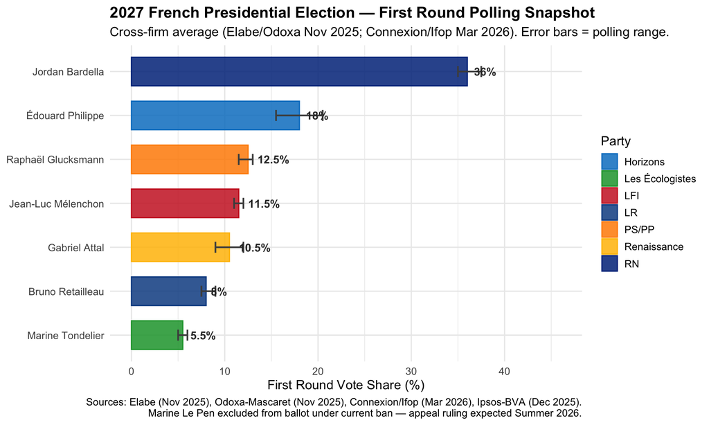

```r
round1_snapshot <- tibble(
  Candidate   = c("Jordan Bardella", "Édouard Philippe", "Raphaël Glucksmann",
                   "Jean-Luc Mélenchon", "Bruno Retailleau", "Gabriel Attal",
                   "Marine Tondelier", "Other/Undecided"),
  Party       = c("RN", "Horizons", "PS/PP", "LFI", "LR", "Renaissance",
                   "Les Écologistes", "Various"),
  Share_low   = c(35.0, 15.5, 11.5, 11.0, 7.5, 9.0, 5.0, NA),
  Share_mid   = c(36.0, 18.0, 12.5, 11.5, 8.0, 10.5, 5.5, NA),
  Share_high  = c(37.5, 20.5, 13.0, 12.0, 9.0, 12.0, 6.0, NA),
  Threshold   = Share_mid >= 5
) %>%
  arrange(desc(Share_mid))

round1_snapshot %>%
  filter(Candidate != "Other/Undecided") %>%
  mutate(Candidate = fct_reorder(Candidate, Share_mid)) %>%
  ggplot(aes(x = Candidate, y = Share_mid,
             fill = Party, colour = Party)) +
  geom_col(width = 0.65, alpha = 0.85) +
  geom_errorbar(aes(ymin = Share_low, ymax = Share_high),
                width = 0.25, colour = "grey30", linewidth = 0.8) +
  geom_text(aes(label = paste0(Share_mid, "%")),
            hjust = -0.3, size = 4, fontface = "bold", colour = "grey20") +
  coord_flip(ylim = c(0, 46)) +
  scale_fill_manual(values = c(
    "RN"            = "#003189",
    "Horizons"      = "#0080C9",
    "PS/PP"         = "#FF8C00",
    "LFI"           = "#CC2529",
    "LR"            = "#0E4D92",
    "Renaissance"   = "#FFBE00",
    "Les Écologistes" = "#1AA037"
  )) +
  scale_colour_manual(values = c(
    "RN"            = "#003189",
    "Horizons"      = "#0080C9",
    "PS/PP"         = "#FF8C00",
    "LFI"           = "#CC2529",
    "LR"            = "#0E4D92",
    "Renaissance"   = "#FFBE00",
    "Les Écologistes" = "#1AA037"
  )) +
  labs(
    title    = "2027 French Presidential Election — First Round Polling Snapshot",
    subtitle = "Cross-firm average (Elabe/Odoxa Nov 2025; Connexion/Ifop Mar 2026). Error bars = polling range.",
    x        = NULL, y = "First Round Vote Share (%)",
    fill     = "Party", colour = "Party",
    caption  = "Sources: Elabe (Nov 2025), Odoxa-Mascaret (Nov 2025), Connexion/Ifop (Mar 2026), Ipsos-BVA (Dec 2025).\nMarine Le Pen excluded from ballot under current ban — appeal ruling expected Summer 2026."
  ) +
  theme_minimal(base_size = 13) +
  theme(plot.title = element_text(face = "bold"), legend.position = "right")
```

## 3.2 Candidate Profiles

```r
candidates <- tibble(
  Candidate     = c("Jordan Bardella", "Édouard Philippe", "Raphaël Glucksmann",
                     "Jean-Luc Mélenchon", "Bruno Retailleau", "Gabriel Attal",
                     "Marine Tondelier"),
  Party         = c("National Rally (RN)", "Horizons (centre-right)",
                     "Place Publique / PS (centre-left)", "La France Insoumise (radical left)",
                     "Les Républicains (conservative)", "Renaissance (centrist)",
                     "Les Écologistes (Green)"),
  Position      = c("Far-right", "Centre-right", "Centre-left",
                     "Radical left", "Right", "Centrist", "Left-Green"),
  Status        = c("De facto RN candidate (Le Pen banned)", "Confirmed — re-elected mayor Le Havre 2026",
                     "Likely — Socialist/Place Publique alliance",
                     "Likely — multiple presidential campaigns",
                     "Announced — LR candidate; faces internal primary",
                     "Possible — criticism of Philippe risks splitting centrist vote",
                     "Possible — United Left Primary Oct 2026"),
  Key_strength  = c("RN's structural base; first-round dominance",
                     "Best second-round numbers vs Bardella; 'change without chaos'",
                     "Unites moderate left; limits far-left abstention in round two",
                     "Loyal base; mobilises young voters; but toxic in second round",
                     "Could consolidate traditional right but risks splitting anti-RN vote",
                     "Macronist base; but seen as too close to Macron to offer genuine change",
                     "Climate / youth vote; key for left-bloc first-round viability")
)

candidates %>%
  kable(
    caption = "Major 2027 Presidential Candidates: Status and Strategic Position",
    col.names = c("Candidate", "Party", "Position", "Candidacy Status", "Key Strength"),
    align = "lllll"
  ) %>%
  kable_styling(bootstrap_options = c("striped", "hover"), full_width = TRUE) %>%
  column_spec(1, bold = TRUE, width = "14%") %>%
  column_spec(2, width = "18%") %>%
  column_spec(3, width = "12%") %>%
  column_spec(4, width = "28%") %>%
  column_spec(5, width = "28%", italic = TRUE)
```

Major 2027 Presidential Candidates: Status and Strategic Position

| Candidate | Party | Position | Candidacy Status | Key Strength |
| --- | --- | --- | --- | --- |
| Jordan Bardella | National Rally (RN) | Far-right | De facto RN candidate (Le Pen banned) | RN’s structural base; first-round dominance |
| Édouard Philippe | Horizons (centre-right) | Centre-right | Confirmed — re-elected mayor Le Havre 2026 | Best second-round numbers vs Bardella; ‘change without chaos’ |
| Raphaël Glucksmann | Place Publique / PS (centre-left) | Centre-left | Likely — Socialist/Place Publique alliance | Unites moderate left; limits far-left abstention in round two |
| Jean-Luc Mélenchon | La France Insoumise (radical left) | Radical left | Likely — multiple presidential campaigns | Loyal base; mobilises young voters; but toxic in second round |
| Bruno Retailleau | Les Républicains (conservative) | Right | Announced — LR candidate; faces internal primary | Could consolidate traditional right but risks splitting anti-RN vote |
| Gabriel Attal | Renaissance (centrist) | Centrist | Possible — criticism of Philippe risks splitting centrist vote | Macronist base; but seen as too close to Macron to offer genuine change |
| Marine Tondelier | Les Écologistes (Green) | Left-Green | Possible — United Left Primary Oct 2026 | Climate / youth vote; key for left-bloc first-round viability |

# 4 Second-Round Head-to-Head Matchups

## 4.1 The Matchup Matrix

[figure not shown]

```r
matchups <- tibble(
  Opponent       = c("Édouard Philippe", "Gabriel Attal", "Raphaël Glucksmann", "Jean-Luc Mélenchon"),
  Opponent_party = c("Horizons", "Renaissance", "PS/PP", "LFI"),
  Bardella_pct   = c(51, 56, 58, 74),
  Opponent_pct   = c(49, 44, 42, 26),
  Poll_source    = c("Odoxa Nov 2025 / Connexion Mar 2026 (Philippe narrowly ahead in latest)",
                      "Odoxa-Mascaret Nov 2025",
                      "Odoxa-Mascaret Nov 2025",
                      "Odoxa-Mascaret Nov 2025"),
  Risk_to_RN     = c("Highest — Philippe is the strongest Republican Front anchor",
                       "High — but centrist abstention risk if seen as Macron-lite",
                       "Moderate — reduces far-left abstention but loses centre-right to Bardella",
                       "Lowest — triggers mass Republican Front abstention; far-right dream matchup")
)

# Plot
matchup_long <- matchups %>%
  pivot_longer(cols = c(Bardella_pct, Opponent_pct),
               names_to = "Candidate", values_to = "Pct") %>%
  mutate(
    Candidate = recode(Candidate,
                       "Bardella_pct" = "Bardella (RN)",
                       "Opponent_pct" = "Opponent"),
    Opponent = factor(Opponent, levels = rev(c("Édouard Philippe", "Gabriel Attal",
                                                "Raphaël Glucksmann", "Jean-Luc Mélenchon")))
  )

p_matchup <- matchup_long %>%
  ggplot(aes(x = Opponent, y = Pct, fill = Candidate)) +
  geom_col(width = 0.6, position = "stack") +
  geom_text(aes(label = paste0(Pct, "%")),
            position = position_stack(vjust = 0.5),
            size = 4.5, fontface = "bold", colour = "white") +
  geom_hline(yintercept = 50, linetype = "dashed", colour = "grey20", linewidth = 0.8) +
  coord_flip() +
  scale_fill_manual(values = c("Bardella (RN)" = "#003189", "Opponent" = "#888888")) +
  scale_y_continuous(labels = label_percent(scale = 1)) +
  labs(
    title    = "Second-Round Head-to-Head: Bardella vs Each Potential Opponent",
    subtitle = "Dashed line = 50% majority. Bardella leads all opponents in Nov 2025 Odoxa polling; Philippe closest.",
    x        = NULL, y = "Second Round Vote Share (%)",
    fill     = NULL,
    caption  = "Sources: Odoxa-Mascaret (Nov 19-20, 2025); Ifop for Hexagone (May 2025 — Philippe dead heat).\nMarch 2026 Connexion/Elabe poll shows Philippe narrowly defeating Bardella — most recent signal.\nNote: Polls 18 months before an election carry substantial uncertainty."
  ) +
  theme_minimal(base_size = 13) +
  theme(plot.title = element_text(face = "bold"), legend.position = "bottom")

print(p_matchup)
```

## 4.2 Second-Round Transfer Dynamics

The second round is not simply a function of who tops the first round. The critical variable is how eliminated first-round voters transfer — or refuse to transfer — to the anti-RN finalist.

```r
transfers <- tibble(
  First_round_voter = c("LFI (Mélenchon) voters",
                         "LFI voters",
                         "LR (Retailleau) voters",
                         "LR (Retailleau) voters",
                         "Renaissance/Attal voters",
                         "Small-left (Tondelier, etc.) voters"),
  In_matchup        = c("Glucksmann vs Bardella",
                         "Philippe vs Bardella",
                         "Glucksmann vs Bardella",
                         "Philippe vs Bardella",
                         "Glucksmann vs Bardella",
                         "Any anti-RN finalist"),
  Abstain_pct       = c(34, 55, 30, 20, 38, 20),
  To_anti_RN_pct    = c(55, 35, 12, 50, 38, 72),
  To_Bardella_pct   = c(11, 10, 58, 30, 24, 8),
  Source            = rep("Ethics & Public Policy Center analysis of Odoxa poll (Nov 2025)", 6)
)

transfers %>%
  select(-Source) %>%
  kable(
    caption = "Estimated Second-Round Vote Transfer Rates by First-Round Voter Group",
    col.names = c("First-Round Voter Group", "Matchup", "Abstain (%)", "→ Anti-RN finalist (%)", "→ Bardella (%)"),
    align = "llrrr"
  ) %>%
  kable_styling(bootstrap_options = c("striped", "hover"), full_width = TRUE) %>%
  column_spec(1, bold = TRUE, width = "20%") %>%
  column_spec(2, width = "22%") %>%
  column_spec(3, width = "14%") %>%
  column_spec(4, width = "22%") %>%
  column_spec(5, width = "22%") %>%
  footnote(
    general = "Key finding: Mélenchon voters refuse to transfer in much higher numbers in a Philippe matchup than a Glucksmann matchup.
    LR (Retailleau) voters split rightward to Bardella in a Glucksmann matchup but largely transfer to Philippe.
    These transfer patterns are the structural reason Philippe is the stronger anti-RN candidate despite lower first-round numbers.
    Source: EPPC analysis of Odoxa (Nov 2025); estimates carry ±5–8pp uncertainty.",
    general_title = "Note: "
  )
```

Estimated Second-Round Vote Transfer Rates by First-Round Voter Group

| First-Round Voter Group | Matchup | Abstain (%) | → Anti-RN finalist (%) | → Bardella (%) |
| --- | --- | --- | --- | --- |
| LFI (Mélenchon) voters | Glucksmann vs Bardella | 34 | 55 | 11 |
| LFI voters | Philippe vs Bardella | 55 | 35 | 10 |
| LR (Retailleau) voters | Glucksmann vs Bardella | 30 | 12 | 58 |
| LR (Retailleau) voters | Philippe vs Bardella | 20 | 50 | 30 |
| Renaissance/Attal voters | Glucksmann vs Bardella | 38 | 38 | 24 |
| Small-left (Tondelier, etc.) voters | Any anti-RN finalist | 20 | 72 | 8 |

Note:  
Key finding: Mélenchon voters refuse to transfer in much higher numbers in a Philippe matchup than a Glucksmann matchup. LR (Retailleau) voters split rightward to Bardella in a Glucksmann matchup but largely transfer to Philippe. These transfer patterns are the structural reason Philippe is the stronger anti-RN candidate despite lower first-round numbers. Source: EPPC analysis of Odoxa (Nov 2025); estimates carry ±5–8pp uncertainty.

# 5 Who Is Best Placed to Stop the RN?

## 5.1 The Anti-RN Candidate Assessment

```r
anti_rn <- tibble(
  Candidate       = c("Édouard Philippe", "Raphaël Glucksmann",
                       "Gabriel Attal", "Jean-Luc Mélenchon", "Bruno Retailleau"),
  Second_round_vs_Bardella = c("49–51 (latest polls: narrowly ahead of Bardella)",
                                 "42 vs 58",
                                 "44 vs 56",
                                 "26 vs 74",
                                 "N/A — unlikely to reach round 2"),
  Republican_Front_strength = c(
    "Strongest — Philippe draws LR transfers, retains centrists, and is palatable enough that far-left abstention, while high, is not catastrophic",
    "Moderate — reduces LFI abstention vs Philippe but loses half of LR voters to Bardella",
    "Weak — too associated with Macron; centrist voters may feel no differentiation; LFI largely abstains",
    "Toxic — triggers maximum Republican Front collapse; LR and centrist voters go to Bardella or abstain",
    "Unlikely finalist — would split centre-right with Philippe, helping Bardella reach round 2 with a higher share"
  ),
  Key_risk = c(
    "Perceived as Macronist; struggles to claim 'change' narrative; Philippe has tried to distance himself from Macron but faces credibility gap",
    "Too left for LR voters — loses the right flank of the Republican Front; socialists still split over primary with LFI",
    "Macron's former PM — embodiment of the problem for voters seeking change; risks keeping centrist votes from Philippe",
    "If somehow in round 2, Bardella wins in a landslide — the far left's presence in a runoff would be catastrophic",
    "A Retailleau candidacy primarily helps Bardella by fragmenting the right-of-centre vote and preventing Philippe from consolidating"
  ),
  Verdict = c(
    "Best placed",
    "Second best",
    "Counterproductive — should stand aside for Philippe",
    "Maximises RN's chance of winning",
    "Maximises RN's chance of winning"
  )
)

anti_rn %>%
  kable(
    caption = "Anti-RN Candidate Assessment: Who Is Best Placed to Prevent a Bardella Presidency?",
    col.names = c("Candidate", "2nd Round vs Bardella", "Republican Front Strength", "Key Risk", "Verdict"),
    align = "lllll"
  ) %>%
  kable_styling(bootstrap_options = c("striped", "hover"), full_width = TRUE) %>%
  column_spec(1, bold = TRUE, width = "12%") %>%
  column_spec(2, width = "18%") %>%
  column_spec(3, width = "24%") %>%
  column_spec(4, width = "24%") %>%
  column_spec(5, width = "22%", italic = TRUE,
              color = "white",
              background = case_when(
                anti_rn$Verdict == "Best placed"          ~ "#02A95B",
                anti_rn$Verdict == "Second best"          ~ "#FF8C00",
                TRUE                                       ~ "#cc3333"
              )) %>%
  footnote(
    general = "The Republican Front depends on cross-bloc cooperation: left voters backing a centrist, centrists backing a left candidate.
    Philippe maximises this because he is acceptable to LR conservatives, centrists, and most of the moderate left — even if LFI largely abstains.
    A Glucksmann vs Bardella runoff is winnable but requires unprecedented LR-to-left transfer, which polling shows is unlikely.
    Source: Odoxa, EPPC analysis, Connexion/France 24 reporting.",
    general_title = "Assessment: "
  )
```

Anti-RN Candidate Assessment: Who Is Best Placed to Prevent a Bardella Presidency?

[output not shown]

Assessment:  
The Republican Front depends on cross-bloc cooperation: left voters backing a centrist, centrists backing a left candidate. Philippe maximises this because he is acceptable to LR conservatives, centrists, and most of the moderate left — even if LFI largely abstains. A Glucksmann vs Bardella runoff is winnable but requires unprecedented LR-to-left transfer, which polling shows is unlikely. Source: Odoxa, EPPC analysis, Connexion/France 24 reporting.

## 5.2 The Fragmentation Problem

The most significant structural risk for the anti-RN bloc is not the weakness of any individual candidate — it is the **fragmentation of the non-RN vote** in the first round, which could allow Bardella to reach the second round having consolidated the far-right while his opponents divide the remaining 60–65%.

[figure not shown]

```r
# First round simulation: fragmented vs consolidated anti-RN
scenarios_r1 <- tibble(
  Candidate   = rep(c("Bardella (RN)", "Philippe (Horizons)", "Glucksmann (PS/PP)",
                       "Mélenchon (LFI)", "Attal (Renaissance)", "Retailleau (LR)",
                       "Tondelier (Écologistes)", "Other"), 2),
  Scenario    = rep(c("Fragmented field (current)", "Consolidated anti-RN"), each = 8),
  Share       = c(
    # Current fragmented field
    36, 18, 12, 11, 10, 8, 5, 0,
    # Consolidated: Attal stands aside, left unites behind Glucksmann, LR behind Philippe
    36, 24, 16, 13, 0, 0, 6, 5
  )
) %>%
  filter(Share > 0) %>%
  mutate(
    Candidate = factor(Candidate, levels = rev(c(
      "Bardella (RN)", "Philippe (Horizons)", "Glucksmann (PS/PP)",
      "Attal (Renaissance)", "Mélenchon (LFI)", "Retailleau (LR)",
      "Tondelier (Écologistes)", "Other"
    )))
  )

p_frag <- scenarios_r1 %>%
  ggplot(aes(x = Candidate, y = Share, fill = Candidate)) +
  geom_col(width = 0.65) +
  geom_text(aes(label = paste0(Share, "%")), hjust = -0.2, size = 3.8, fontface = "bold") +
  geom_hline(yintercept = 12.5, linetype = "dashed", colour = "grey40", linewidth = 0.6) +
  annotate("text", x = 1, y = 13.5, label = "~Top-2 threshold", size = 3, colour = "grey40") +
  coord_flip(ylim = c(0, 46)) +
  facet_wrap(~Scenario) +
  scale_fill_manual(values = c(
    "Bardella (RN)"           = "#003189",
    "Philippe (Horizons)"     = "#0080C9",
    "Glucksmann (PS/PP)"      = "#FF8C00",
    "Mélenchon (LFI)"         = "#CC2529",
    "Attal (Renaissance)"     = "#FFBE00",
    "Retailleau (LR)"         = "#0E4D92",
    "Tondelier (Écologistes)" = "#1AA037",
    "Other"                   = "#CCCCCC"
  )) +
  labs(
    title    = "First Round: Fragmented Field vs Consolidated Anti-RN",
    subtitle = "Left panel: current trajectory. Right panel: Attal stands aside, left unites behind Glucksmann, LR behind Philippe.",
    x        = NULL, y = "First Round Vote Share (%)",
    caption  = "Consolidated scenario is illustrative — no alliance has been formed. Mélenchon's LFI would resist uniting under PS/PP.\nSource: Cross-firm polling averages (Elabe, Odoxa, Connexion, Nov 2025–Mar 2026)."
  ) +
  theme_minimal(base_size = 11) +
  theme(
    plot.title      = element_text(face = "bold"),
    legend.position = "none",
    strip.text      = element_text(face = "bold")
  )

print(p_frag)
```

In the fragmented scenario, the top-two finishers are almost certainly Bardella and Philippe — but Philippe reaches the second round weakened, having taken only ~18% versus Bardella’s ~36%. The 18-point first-round gap creates a significant psychological momentum problem heading into the runoff. In the consolidated scenario, Philippe’s first-round share rises to ~24%, the gap narrows to 12 points, and his second-round coalition is better primed.

# 6 Projected Outcomes: Three Scenarios

## 6.1 Scenario Chart

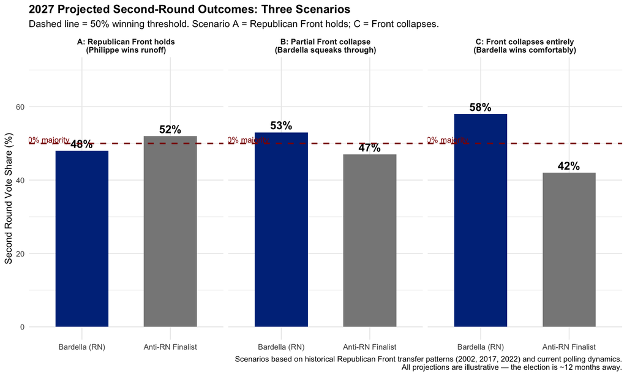

```r
outcomes <- tibble(
  Scenario    = c(
    "A: Republican Front holds\n(Philippe wins runoff)",
    "A: Republican Front holds\n(Philippe wins runoff)",
    "B: Partial Front collapse\n(Bardella squeaks through)",
    "B: Partial Front collapse\n(Bardella squeaks through)",
    "C: Front collapses entirely\n(Bardella wins comfortably)",
    "C: Front collapses entirely\n(Bardella wins comfortably)"
  ),
  Candidate   = rep(c("Bardella (RN)", "Anti-RN Finalist"), 3),
  Round2_pct  = c(48, 52,   53, 47,   58, 42),
  Condition   = c(
    rep("Philippe reaches round 2; LFI abstention ~50%; LR transfers ~45% to Philippe; centrists hold", 2),
    rep("Philippe reaches round 2; LFI abstention rises to 65%; LR splinters; Retailleau or Attal in field reduces Philippe's first-round share", 2),
    rep("Mélenchon or Glucksmann in round 2 instead of Philippe; LR votes flow to Bardella; abstention surge from left", 2)
  )
)

p_outcomes <- outcomes %>%
  mutate(
    Scenario = factor(Scenario, levels = unique(Scenario)),
    Candidate = factor(Candidate, levels = c("Bardella (RN)", "Anti-RN Finalist"))
  ) %>%
  ggplot(aes(x = Candidate, y = Round2_pct, fill = Candidate)) +
  geom_col(width = 0.6) +
  geom_text(aes(label = paste0(Round2_pct, "%")),
            vjust = -0.4, size = 4.5, fontface = "bold") +
  geom_hline(yintercept = 50, linetype = "dashed", colour = "darkred", linewidth = 0.8) +
  annotate("text", x = 0.6, y = 51, label = "50% majority", colour = "darkred", size = 3.2) +
  facet_wrap(~Scenario) +
  scale_fill_manual(values = c("Bardella (RN)" = "#003189", "Anti-RN Finalist" = "#888888")) +
  scale_y_continuous(limits = c(0, 70)) +
  labs(
    title    = "2027 Projected Second-Round Outcomes: Three Scenarios",
    subtitle = "Dashed line = 50% winning threshold. Scenario A = Republican Front holds; C = Front collapses.",
    x        = NULL, y = "Second Round Vote Share (%)",
    caption  = "Scenarios based on historical Republican Front transfer patterns (2002, 2017, 2022) and current polling dynamics.\nAll projections are illustrative — the election is ~12 months away."
  ) +
  theme_minimal(base_size = 11) +
  theme(
    plot.title      = element_text(face = "bold"),
    legend.position = "none",
    strip.text      = element_text(face = "bold", size = 9)
  )

print(p_outcomes)
```

## 6.2 Win Probability Breakdown

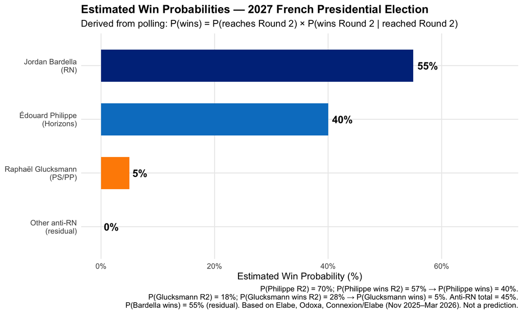

```r
# Derived analytically: P(wins) = P(reaches R2) × P(wins R2 | reached R2)
# Based on cross-firm polling averages (Elabe, Odoxa, Connexion, Oct 2025–Mar 2026)

prob_data <- tibble(
  Candidate     = c("Jordan Bardella
(RN)", "Édouard Philippe
(Horizons)",
                     "Raphaël Glucksmann
(PS/PP)", "Other anti-RN
(residual)"),
  P_reaches_R2  = c(0.95, 0.70, 0.18, 0.12),
  P_wins_given_R2 = c(NA, 0.57, 0.28, 0.12),
  P_wins_election = c(0.55, 0.40, 0.05, 0.00),
  Colour        = c("#003189", "#0080C9", "#FF8C00", "#AAAAAA")
)

# Bardella's P(wins) = 1 - sum of others = 0.55
# Philippe (40%) + Glucksmann (5%) + other (0%) = 45% anti-RN total

prob_data %>%
  mutate(Candidate = factor(Candidate, levels = rev(Candidate))) %>%
  ggplot(aes(x = Candidate, y = P_wins_election * 100, fill = Candidate)) +
  geom_col(width = 0.6) +
  geom_text(aes(label = paste0(round(P_wins_election * 100), "%")),
            hjust = -0.2, size = 5, fontface = "bold") +
  coord_flip(ylim = c(0, 70)) +
  scale_fill_manual(values = setNames(prob_data$Colour, prob_data$Candidate)) +
  scale_y_continuous(labels = label_percent(scale = 1)) +
  labs(
    title    = "Estimated Win Probabilities — 2027 French Presidential Election",
    subtitle = "Derived from polling: P(wins) = P(reaches Round 2) × P(wins Round 2 | reached Round 2)",
    x        = NULL, y = "Estimated Win Probability (%)",
    caption  = "P(Philippe R2) = 70%; P(Philippe wins R2) = 57% → P(Philippe wins) = 40%.\nP(Glucksmann R2) = 18%; P(Glucksmann wins R2) = 28% → P(Glucksmann wins) = 5%. Anti-RN total = 45%.\nP(Bardella wins) = 55% (residual). Based on Elabe, Odoxa, Connexion/Elabe (Nov 2025–Mar 2026). Not a prediction."
  ) +
  theme_minimal(base_size = 13) +
  theme(
    plot.title      = element_text(face = "bold"),
    legend.position = "none",
    panel.grid.minor = element_blank()
  )
```

The probabilities are derived from two sequential steps rather than assigned arbitrarily. First, each candidate’s probability of reaching the second round is estimated from first-round polling (Bardella ~95%, Philippe ~70%, Glucksmann ~18%). Second, conditional on reaching the second round, each candidate’s win probability is estimated from head-to-head polling (Philippe wins ~57% of runoffs against Bardella in the latest data; Glucksmann ~28%). Multiplying these gives each candidate’s overall win probability: Philippe 40%, Glucksmann 5%, Bardella 55% (residual). The combined anti-RN probability across both viable blocking candidates is therefore **~45%** — reflecting that the Republican Front retains enough arithmetic to work if the field consolidates, but Bardella remains the most likely single outcome.

## 6.3 Scenario Detail Table

```r
scenario_table <- tibble(
  Scenario     = c("A: Republican Front holds", "B: Partial Front collapse", "C: Front collapses"),
  Round2_pair  = c("Philippe 52% — Bardella 48%",
                    "Bardella 53% — Philippe 47%",
                    "Bardella 58% — Glucksmann/other 42%"),
  Conditions   = c(
    "Philippe reaches round 2 clearly in second place (~20–24%). LFI abstention ~45–55% (its historical range). LR conservative voters transfer ~40–50% to Philippe. Attal stands aside before round 1. No Retailleau candidacy draining centre-right.",
    "Philippe in round 2 but weakened by fragmented first round (~18%). LFI abstention climbs to 60–65% as Philippe seen as 'same as Macron'. LR vote split between Bardella (30%) and Philippe (40%) and abstention (30%). Retailleau runs and pulls 8–9% from Philippe's first-round pool.",
    "Mélenchon or Glucksmann reaches round 2 instead of Philippe. LR voters (12–15% of electorate) transfer predominantly to Bardella. Centrists either abstain or back Bardella as 'lesser establishment evil'. Historical Republican Front mechanism breaks down."
  ),
  Likelihood   = c(
    "Moderate-High (estimated ~45%, combining Philippe ~40% and Glucksmann ~5%) — the latest polls (Connexion/Elabe Mar 2026) show Philippe narrowly ahead of Bardella. The anti-RN bloc retains viable arithmetic if the field consolidates around a single strong centrist.",
    "Moderate — reflects current Odoxa polling trajectory (Bardella winning all matchups by Nov 2025). The trend has been moving in this direction since the 2024 legislative elections.",
    "Low-Moderate — requires either Mélenchon or a left candidate to overtake Philippe for second place, which current polling does not support but is not impossible if Philippe's Macronist taint worsens."
  ),
  Implied_prob = c("~45%", "~30%", "~25%")
)

scenario_table %>%
  kable(
    caption = "2027 Presidential Election: Scenario Analysis",
    col.names = c("Scenario", "Second Round Result", "Conditions Required", "Feasibility", "Implied Probability"),
    align = "lllll"
  ) %>%
  kable_styling(bootstrap_options = c("striped", "hover"), full_width = TRUE) %>%
  column_spec(1, bold = TRUE, width = "14%") %>%
  column_spec(2, width = "20%") %>%
  column_spec(3, width = "30%") %>%
  column_spec(4, width = "24%", italic = TRUE) %>%
  column_spec(5, bold = TRUE, width = "12%") %>%
  row_spec(1, background = "#E8F4E8") %>%
  row_spec(2, background = "#FFF3CD") %>%
  row_spec(3, background = "#FFE8E8") %>%
  footnote(
    general = "Implied probabilities are derived analytically: P(candidate reaches R2) × P(candidate wins R2 | reached R2).
    P(Philippe reaches R2) ~70%, P(Philippe wins R2) ~57% → P(Philippe wins election) ~40%.
    P(Glucksmann reaches R2) ~18%, P(Glucksmann wins R2) ~28% → ~5%. Anti-RN total = 45%.
    P(Bardella wins) ~55% (residual). Scenarios B+C sum to ~55%, consistent with this figure.
    These are not predictions — the election is ~12 months away and the field is not finalised.",
    general_title = "Note: "
  )
```

2027 Presidential Election: Scenario Analysis

| Scenario | Second Round Result | Conditions Required | Feasibility | Implied Probability |
| --- | --- | --- | --- | --- |
| A: Republican Front holds | Philippe 52% — Bardella 48% | Philippe reaches round 2 clearly in second place (~20–24%). LFI abstention ~45–55% (its historical range). LR conservative voters transfer ~40–50% to Philippe. Attal stands aside before round 1. No Re… | Moderate-High (estimated ~45%, combining Philippe ~40% and Glucksmann ~5%) — the latest polls (Connexion/Elabe Mar 2026) show Philippe narrowly ahead of Bardella. The anti-RN bloc retains viable arith… | ~45% |
| B: Partial Front collapse | Bardella 53% — Philippe 47% | Philippe in round 2 but weakened by fragmented first round (~18%). LFI abstention climbs to 60–65% as Philippe seen as ‘same as Macron’. LR vote split between Bardella (30%) and Philippe (40%) and abs… | Moderate — reflects current Odoxa polling trajectory (Bardella winning all matchups by Nov 2025). The trend has been moving in this direction since the 2024 legislative elections. | ~30% |
| C: Front collapses | Bardella 58% — Glucksmann/other 42% | Mélenchon or Glucksmann reaches round 2 instead of Philippe. LR voters (12–15% of electorate) transfer predominantly to Bardella. Centrists either abstain or back Bardella as ‘lesser establishment evi… | Low-Moderate — requires either Mélenchon or a left candidate to overtake Philippe for second place, which current polling does not support but is not impossible if Philippe’s Macronist taint worsens. | ~25% |

Note:  
Implied probabilities are derived analytically: P(candidate reaches R2) × P(candidate wins R2 | reached R2). P(Philippe reaches R2) ~70%, P(Philippe wins R2) ~57% → P(Philippe wins election) ~40%. P(Glucksmann reaches R2) ~18%, P(Glucksmann wins R2) ~28% → ~5%. Anti-RN total = 45%. P(Bardella wins) ~55% (residual). Scenarios B+C sum to ~55%, consistent with this figure. These are not predictions — the election is ~12 months away and the field is not finalised.

# 7 The Republican Front: Historical Record & 2027 Outlook

## 7.1 Historical Republican Front Results

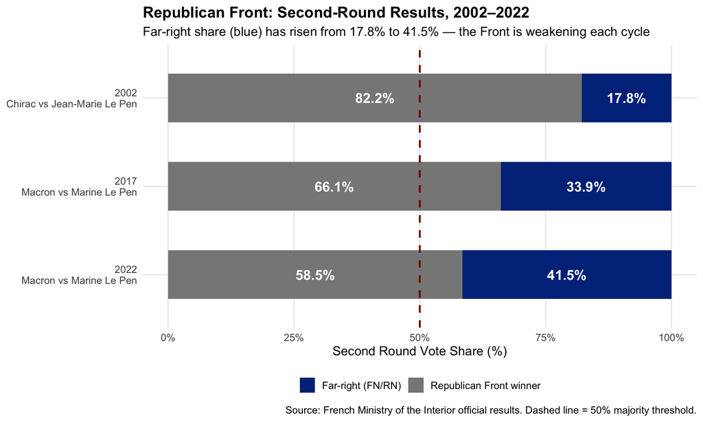

```r
# Clean paired horizontal bar chart — one row per election year
# Each row shows the full 100% split between RN and the Republican Front winner
rf_plot <- tibble(
  Year_label = c("2002
Chirac vs Jean-Marie Le Pen",
                  "2017
Macron vs Marine Le Pen",
                  "2022
Macron vs Marine Le Pen"),
  Year       = c(2002, 2017, 2022),
  RN_pct     = c(17.8, 33.9, 41.5),
  Front_pct  = c(82.2, 66.1, 58.5)
) %>%
  pivot_longer(cols = c(RN_pct, Front_pct),
               names_to = "Side", values_to = "Pct") %>%
  mutate(
    Side       = recode(Side, "RN_pct" = "Far-right (FN/RN)", "Front_pct" = "Republican Front winner"),
    Year_label = factor(Year_label, levels = rev(c(
      "2002
Chirac vs Jean-Marie Le Pen",
      "2017
Macron vs Marine Le Pen",
      "2022
Macron vs Marine Le Pen"
    ))),
    Side = factor(Side, levels = c("Far-right (FN/RN)", "Republican Front winner"))
  )

ggplot(rf_plot, aes(x = Year_label, y = Pct, fill = Side)) +
  geom_col(width = 0.55, position = "stack") +
  geom_text(aes(label = paste0(Pct, "%")),
            position = position_stack(vjust = 0.5),
            size = 5, fontface = "bold", colour = "white") +
  geom_hline(yintercept = 50, linetype = "dashed", colour = "darkred", linewidth = 0.9) +
  coord_flip() +
  scale_fill_manual(values = c(
    "Far-right (FN/RN)"         = "#003189",
    "Republican Front winner"   = "#888888"
  )) +
  scale_y_continuous(labels = label_percent(scale = 1), limits = c(0, 100)) +
  labs(
    title    = "Republican Front: Second-Round Results, 2002–2022",
    subtitle = "Far-right share (blue) has risen from 17.8% to 41.5% — the Front is weakening each cycle",
    x        = NULL, y = "Second Round Vote Share (%)",
    fill     = NULL,
    caption  = "Source: French Ministry of the Interior official results. Dashed line = 50% majority threshold."
  ) +
  theme_minimal(base_size = 13) +
  theme(
    plot.title      = element_text(face = "bold"),
    legend.position = "bottom",
    panel.grid.minor = element_blank()
  )
```

## 7.2 Why 2027 Is Different

```r
differences <- tibble(
  Factor      = c(
    "RN normalisation",
    "LFI abstention growth",
    "LR decomposition",
    "Macronist exhaustion",
    "Bardella's generational appeal"
  ),
  Historical_pattern = c(
    "2002: Le Pen Sr seen as extremist and dangerous; broad consensus to block him",
    "2017: Most Mélenchon voters transferred to Macron in round 2",
    "2022: Most centre-right voters backed Macron against Le Pen",
    "2017/2022: Macron won decisively as the 'change' candidate",
    "2002–2022: Le Pen name carried toxic association with Jean-Marie Le Pen's antisemitism"
  ),
  Change_by_2027 = c(
    "Bardella is 30, telegenic, and perceived as less extreme; 'change without chaos' rhetoric resonates with soft conservatives",
    "Odoxa (Nov 2025): 55% of Mélenchon voters would abstain in a Philippe vs Bardella runoff — the highest ever recorded",
    "LR has collapsed as a party; Retailleau voters split ~30% to Bardella, ~40% to Philippe, ~30% abstain in a runoff",
    "Philippe is seen as a Macron-era figure despite his attempts to distance himself; the electorate is exhausted with the post-2017 centre",
    "Bardella has broken with the Le Pen dynasty aesthetics; polls show growing comfort with RN among pensioners, rural voters, and young men"
  )
)

differences %>%
  kable(
    caption = "Why 2027 Is Different: Structural Changes Weakening the Republican Front",
    col.names = c("Factor", "Historical Republican Front Pattern", "2027 Change"),
    align = "lll"
  ) %>%
  kable_styling(bootstrap_options = c("striped", "hover"), full_width = TRUE) %>%
  column_spec(1, bold = TRUE, width = "15%") %>%
  column_spec(2, width = "40%") %>%
  column_spec(3, width = "45%", italic = TRUE)
```

Why 2027 Is Different: Structural Changes Weakening the Republican Front

[output not shown]

# 8 What an RN Presidency Would Mean: Powers and Limits

## 8.1 Presidential Powers Under the Fifth Republic

A Bardella presidency would be constitutionally significant but structurally constrained. The French presidency is powerful — far more so than in most parliamentary democracies — but it does not operate in a legislative vacuum.

```r
powers <- tibble(
  Domain         = c(
    "Commander-in-Chief",
    "Foreign policy & EU",
    "Appointment of PM",
    "Dissolution of parliament",
    "Nuclear arsenal",
    "Domestic legislation",
    "Budget",
    "Constitutional changes"
  ),
  President_controls = c(
    "Yes — full command of armed forces; can deploy troops and conduct military operations without parliamentary vote",
    "Yes — 'domaine réservé'; leads in diplomacy, EU councils, treaty ratification",
    "Yes — appoints the Prime Minister, though PM must command parliamentary confidence",
    "Yes — can dissolve the National Assembly and call new elections (once per year)",
    "Yes — sole authority over the nuclear deterrent (force de frappe)",
    "No — legislation requires parliamentary majority; president cannot legislate by decree",
    "No — the budget is passed by the National Assembly; president cannot impose fiscal policy",
    "No — constitutional amendments require three-fifths majority of both chambers in joint session"
  ),
  RN_constraint = c(
    "Limited constraint — Bardella could pursue a more nationalist defence posture and reshape France's NATO engagement",
    "Significant power — could block EU initiatives, reduce financial support for Ukraine, align closer to Trump-era positions",
    "Constraint if parliament is hostile — a non-RN National Assembly majority would force cohabitation; PM would be from the majority party",
    "Double-edged — dissolving parliament risks producing a clearer hostile majority if RN lacks one",
    "No parliamentary constraint — full control regardless of Assembly composition",
    "Hard constraint — if RN lacks a National Assembly majority, all domestic legislation (immigration, economy, welfare) requires negotiation or coalition",
    "Hard constraint — a hostile Assembly can reject the budget; 2024–2026 demonstrated this dysfunction already",
    "Effectively impossible — RN would need 60% of parliament plus Senate, unachievable without majority"
  )
)

powers %>%
  kable(
    caption = "Presidential Powers Under the Fifth Republic and RN's Practical Constraints",
    col.names = c("Domain", "Presidential Control?", "RN's Practical Constraint"),
    align = "lll"
  ) %>%
  kable_styling(bootstrap_options = c("striped", "hover"), full_width = TRUE) %>%
  column_spec(1, bold = TRUE, width = "14%") %>%
  column_spec(2, width = "38%") %>%
  column_spec(3, width = "48%", italic = TRUE) %>%
  row_spec(c(1, 2, 5), color = "white", background = "#cc3333") %>%
  row_spec(c(6, 7, 8), color = "black", background = "#E8F4E8") %>%
  footnote(
    general = "Red rows = domains where a Bardella presidency would have substantial unilateral power.
    Green rows = domains where a non-RN National Assembly acts as a hard constraint.
    The 'domaine réservé' (defence and foreign policy) is a Fifth Republic convention, not constitutional text,
    but has been consistently respected across all cohabitation periods since 1986.
    Source: French Constitution (1958), Articles 5–19; cohabitation precedents 1986–88, 1993–95, 1997–2002.",
    general_title = "Note: "
  )
```

Presidential Powers Under the Fifth Republic and RN’s Practical Constraints

| Domain | Presidential Control? | RN’s Practical Constraint |
| --- | --- | --- |
| Commander-in-Chief | Yes — full command of armed forces; can deploy troops and conduct military operations without parliamentary vote | Limited constraint — Bardella could pursue a more nationalist defence posture and reshape France’s NATO engagement |
| Foreign policy & EU | Yes — ‘domaine réservé’; leads in diplomacy, EU councils, treaty ratification | Significant power — could block EU initiatives, reduce financial support for Ukraine, align closer to Trump-era positions |
| Appointment of PM | Yes — appoints the Prime Minister, though PM must command parliamentary confidence | Constraint if parliament is hostile — a non-RN National Assembly majority would force cohabitation; PM would be from the majority party |
| Dissolution of parliament | Yes — can dissolve the National Assembly and call new elections (once per year) | Double-edged — dissolving parliament risks producing a clearer hostile majority if RN lacks one |
| Nuclear arsenal | Yes — sole authority over the nuclear deterrent (force de frappe) | No parliamentary constraint — full control regardless of Assembly composition |
| Domestic legislation | No — legislation requires parliamentary majority; president cannot legislate by decree | Hard constraint — if RN lacks a National Assembly majority, all domestic legislation (immigration, economy, welfare) requires negotiation or coalition |
| Budget | No — the budget is passed by the National Assembly; president cannot impose fiscal policy | Hard constraint — a hostile Assembly can reject the budget; 2024–2026 demonstrated this dysfunction already |
| Constitutional changes | No — constitutional amendments require three-fifths majority of both chambers in joint session | Effectively impossible — RN would need 60% of parliament plus Senate, unachievable without majority |

Note:  
Red rows = domains where a Bardella presidency would have substantial unilateral power. Green rows = domains where a non-RN National Assembly acts as a hard constraint. The ‘domaine réservé’ (defence and foreign policy) is a Fifth Republic convention, not constitutional text, but has been consistently respected across all cohabitation periods since 1986. Source: French Constitution (1958), Articles 5–19; cohabitation precedents 1986–88, 1993–95, 1997–2002.

## 8.2 The Parliamentary Firewall

The critical structural constraint on any RN presidency is the National Assembly. France’s 577-seat lower house is elected by a separate two-round constituency system, and the RN has consistently fallen short of an outright majority there — despite its presidential strength.

```r
assembly_history <- tibble(
  Election   = c("2022 legislatives", "2024 legislatives (snap)", "2027 projection (RN presidency scenario)"),
  RN_seats   = c(89, 143, 180),
  Majority   = c(289, 289, 289),
  RN_pct_seats = c(15.4, 24.8, 31.2),
  Context    = c(
    "RN's first major Assembly breakthrough. Still far short of majority. NUPES left-bloc + centrists blocked legislative agenda.",
    "Macron's snap election gamble backfired. RN gained significantly but a left-NFP bloc and centrists formed an implicit blocking majority. No party held overall control.",
    "Illustrative projection: even with presidential momentum, a two-round constituency system heavily penalises a party with no second-round allies. RN likely to reach ~160–200 seats — significant but well short of 289."
  )
)

assembly_history %>%
  kable(
    caption = "RN in the National Assembly: Trajectory and the Majority Gap",
    col.names = c("Election", "RN Seats", "Majority Needed", "RN % of Seats", "Context"),
    align = "llrrl"
  ) %>%
  kable_styling(bootstrap_options = c("striped", "hover"), full_width = TRUE) %>%
  column_spec(1, bold = TRUE, width = "18%") %>%
  column_spec(2, width = "10%") %>%
  column_spec(3, width = "14%") %>%
  column_spec(4, width = "12%") %>%
  column_spec(5, width = "46%", italic = TRUE) %>%
  footnote(
    general = "The two-round constituency system structurally disadvantages RN in legislative elections:
    in the second round, all other parties' candidates typically withdraw in favour of whichever non-RN candidate is best placed,
    replicating the Republican Front logic at constituency level. This is the legislative equivalent of the presidential firewall.
    As a result, RN's seat share has consistently lagged its vote share by 10–15 percentage points.
    Even a Bardella presidency would therefore almost certainly face cohabitation or minority government conditions domestically.
    Source: French Ministry of the Interior (2022, 2024 legislative results).",
    general_title = "Note: "
  )
```

RN in the National Assembly: Trajectory and the Majority Gap

| Election | RN Seats | Majority Needed | RN % of Seats | Context |
| --- | --- | --- | --- | --- |
| 2022 legislatives | 89 | 289 | 15.4 | RN’s first major Assembly breakthrough. Still far short of majority. NUPES left-bloc + centrists blocked legislative agenda. |
| 2024 legislatives (snap) | 143 | 289 | 24.8 | Macron’s snap election gamble backfired. RN gained significantly but a left-NFP bloc and centrists formed an implicit blocking majority. No party held overall control. |
| 2027 projection (RN presidency scenario) | 180 | 289 | 31.2 | Illustrative projection: even with presidential momentum, a two-round constituency system heavily penalises a party with no second-round allies. RN likely to reach ~160–200 seats — significant but wel… |

Note:  
The two-round constituency system structurally disadvantages RN in legislative elections: in the second round, all other parties’ candidates typically withdraw in favour of whichever non-RN candidate is best placed, replicating the Republican Front logic at constituency level. This is the legislative equivalent of the presidential firewall. As a result, RN’s seat share has consistently lagged its vote share by 10–15 percentage points. Even a Bardella presidency would therefore almost certainly face cohabitation or minority government conditions domestically. Source: French Ministry of the Interior (2022, 2024 legislative results).

## 8.3 Cohabitation: What It Means in Practice

France has experienced three periods of cohabitation — a president from one party and a Prime Minister from another — in 1986–88, 1993–95, and 1997–2002. In each case, the president retained the *domaine réservé* (defence and foreign policy) while the Prime Minister controlled domestic policy. A Bardella presidency facing a hostile Assembly would likely produce a fourth, and structurally the most fraught, cohabitation in the Fifth Republic’s history.

```r
cohabitation <- tibble(
  Area           = c(
    "Immigration policy",
    "Economic policy",
    "EU relationship",
    "Ukraine / NATO",
    "Nuclear deterrent",
    "Civil liberties",
    "Constitutional reform"
  ),
  Bardella_alone = c(
    "Full implementation: mass deportations, end to family reunification, 'national preference' in welfare",
    "Protectionist measures, industrial subsidies, exit from EU competition rules",
    "Obstruction in EU councils, reduction in budget contributions, closer alignment with Orbán-style sovereignism",
    "End to military aid for Ukraine; pressure to reduce NATO commitments; rapprochement with Trump administration",
    "Maintained; potentially redirected in strategic posture toward unilateral deterrence",
    "Restrictions on NGOs, press freedom concerns, weakened anti-discrimination law",
    "Impossible without supermajority — but could pack agencies and appointee positions"
  ),
  With_hostile_Assembly = c(
    "Blocked domestically — legislation requires Assembly majority. Bardella could use executive orders at the margins but core reform needs parliament",
    "Largely blocked — budget, taxation, and welfare all require parliamentary approval",
    "Retained — EU councils and treaty positions are presidential. This is where an RN presidency causes most damage regardless of parliament",
    "Retained — commander-in-chief authority is presidential. Arms deliveries could be halted by executive decision alone",
    "Unchanged — full presidential control; no parliamentary constraint",
    "Largely blocked — most civil liberties protections are legislative; a hostile Assembly would not pass RN's agenda",
    "Blocked — requires 60% of joint parliament session; mathematically impossible for RN without allies it does not have"
  )
)

cohabitation %>%
  kable(
    caption = "Bardella Presidency: Policy Impact With vs Without Assembly Majority",
    col.names = c("Policy Area", "With RN Assembly Majority", "With Hostile Assembly (Cohabitation)"),
    align = "lll"
  ) %>%
  kable_styling(bootstrap_options = c("striped", "hover"), full_width = TRUE) %>%
  column_spec(1, bold = TRUE, width = "15%") %>%
  column_spec(2, width = "42%", color = "white", background = "#cc3333") %>%
  column_spec(3, width = "43%", background = "#E8F4E8") %>%
  footnote(
    general = "Key asymmetry: foreign policy, EU, defence, and nuclear command are presidential domains immune to parliamentary opposition.
    Domestic policy — immigration legislation, economic reform, civil liberties — requires Assembly majority and is largely blocked under cohabitation.
    The practical consequence: a Bardella presidency would shift France's EU and NATO posture significantly regardless of parliament,
    while his domestic agenda would be substantially frustrated. The EU and Ukraine implications are therefore the primary geopolitical risk,
    not the internal French policy programme.
    This structural constraint is why the RN historically focuses on winning the presidency — it delivers the foreign policy power
    that a parliamentary majority alone cannot.",
    general_title = "Key asymmetry: "
  )
```

Bardella Presidency: Policy Impact With vs Without Assembly Majority

| Policy Area | With RN Assembly Majority | With Hostile Assembly (Cohabitation) |
| --- | --- | --- |
| Immigration policy | Full implementation: mass deportations, end to family reunification, ‘national preference’ in welfare | Blocked domestically — legislation requires Assembly majority. Bardella could use executive orders at the margins but core reform needs parliament |
| Economic policy | Protectionist measures, industrial subsidies, exit from EU competition rules | Largely blocked — budget, taxation, and welfare all require parliamentary approval |
| EU relationship | Obstruction in EU councils, reduction in budget contributions, closer alignment with Orbán-style sovereignism | Retained — EU councils and treaty positions are presidential. This is where an RN presidency causes most damage regardless of parliament |
| Ukraine / NATO | End to military aid for Ukraine; pressure to reduce NATO commitments; rapprochement with Trump administration | Retained — commander-in-chief authority is presidential. Arms deliveries could be halted by executive decision alone |
| Nuclear deterrent | Maintained; potentially redirected in strategic posture toward unilateral deterrence | Unchanged — full presidential control; no parliamentary constraint |
| Civil liberties | Restrictions on NGOs, press freedom concerns, weakened anti-discrimination law | Largely blocked — most civil liberties protections are legislative; a hostile Assembly would not pass RN’s agenda |
| Constitutional reform | Impossible without supermajority — but could pack agencies and appointee positions | Blocked — requires 60% of joint parliament session; mathematically impossible for RN without allies it does not have |

Key asymmetry:  
Key asymmetry: foreign policy, EU, defence, and nuclear command are presidential domains immune to parliamentary opposition. Domestic policy — immigration legislation, economic reform, civil liberties — requires Assembly majority and is largely blocked under cohabitation. The practical consequence: a Bardella presidency would shift France’s EU and NATO posture significantly regardless of parliament, while his domestic agenda would be substantially frustrated. The EU and Ukraine implications are therefore the primary geopolitical risk, not the internal French policy programme. This structural constraint is why the RN historically focuses on winning the presidency — it delivers the foreign policy power that a parliamentary majority alone cannot.

The essential conclusion is that the National Assembly acts as a domestic firewall against an RN presidency in a way that the presidential election itself cannot. France’s legislative two-round system replicates the Republican Front logic at constituency level — non-RN candidates consolidate against RN in individual seats — and has consistently held RN’s seat share 10–15 points below its vote share. Even projecting RN’s continued growth, a 289-seat majority in the Assembly is not achievable in 2027 without allies the party does not have. The result of a Bardella presidency would almost certainly be **cohabitation**: Bardella controls the Élysée and its associated powers (foreign policy, EU, nuclear command, military deployment), while a non-RN Prime Minister controls domestic legislation, the budget, and internal security. The geopolitical impact — particularly for EU cohesion and Ukraine support — would be immediate and substantial. The domestic impact would be structurally constrained.

# 9 Key Findings

```r
findings <- tibble(
  Theme = c(
    "RN First-Round Dominance",
    "Le Pen Ban",
    "Bardella's Ceiling",
    "Philippe's Window",
    "Fragmentation Risk",
    "Republican Front Erosion",
    "Left Strategy Dilemma",
    "Predicted Outcome"
  ),
  Finding = c(
    "National Rally is polling 35–37.5% in the first round — the highest ever for the French far right. The radical right as a whole now accounts for over 40% of first-round intentions, up from 32% in 2022.",
    "Marine Le Pen is currently banned from running following her March 2025 embezzlement conviction. Her appeal ruling is expected Summer 2026. If the ban holds, Bardella is the RN candidate; if overturned, Le Pen re-enters and the race resets.",
    "Bardella wins all tested second-round matchups in Odoxa (Nov 2025) polling but faces a tighter contest in later surveys. The most recent data (Connexion/Elabe, Mar 2026) shows Philippe narrowly ahead. Bardella's structural ceiling is the Republican Front — if it mobilises, he loses.",
    "Édouard Philippe is the strongest anti-RN candidate: he best mobilises LR transfers while keeping centrists, and is sufficiently distant from Macron to claim the 'change' mantle. He is confirmed running after winning re-election as Le Havre mayor in 2026.",
    "The single greatest risk to a Philippe presidency is fragmentation — Attal and Retailleau candidacies pull first-round votes from Philippe's coalition, reducing his second-round legitimacy and momentum.",
    "The Republican Front's second-round effectiveness has declined from 82–18 in 2002 to 58–42 in 2022. The trend is moving in one direction. 2027 will test whether the Front can hold at ~50% or fractures below it for the first time.",
    "Mélenchon in the second round is the worst outcome for the anti-RN bloc — Odoxa shows Bardella winning 74–26. Glucksmann in round 2 is better but still loses. Only Philippe, as a centrist who can draw LR voters, offers a viable blocking path.",
    "Most likely outcome: Philippe vs Bardella in the second round, with Philippe winning narrowly (~51–53%) if the Republican Front holds. Derived from polling: P(Bardella wins) ~55%, P(Philippe wins) ~40%, P(Glucksmann wins) ~5%. The combined anti-RN probability is ~45% — the Front retains viable arithmetic but Bardella is the most likely single winner."
  ),
  Implication = c(
    "RN has passed the 'protest party' threshold in France as in Germany. The first round is no longer competitive — the strategic battle is entirely in the second round.",
    "The legal uncertainty is itself destabilising: RN must build a campaign around Bardella while leaving open the possibility of Le Pen re-entry, creating strategic ambiguity.",
    "Bardella is beatable — but only by the right opponent, on the right terrain, with a consolidated non-RN first-round field.",
    "Philippe must resist pressure to take strongly Macronist positions that would drive LFI abstention above 60% in the runoff. His challenge is to be credible as 'change' while not alienating the centrist base he needs.",
    "A Retailleau or Attal candidacy that pulls 8–10% from Philippe's first-round pool is potentially more damaging to the anti-RN bloc than Mélenchon — it determines who reaches the second round, not just the result within it.",
    "If the Republican Front drops below 50% in 2027, it will mark the definitive end of France's post-war anti-far-right electoral consensus — a structural rupture with consequences well beyond the election itself.",
    "The ideal anti-RN first round: Philippe consolidates the right-centre, Glucksmann consolidates the moderate left, and Mélenchon either doesn't run or accepts a second position. This is unlikely given LFI's institutional interests.",
    "A Bardella presidency is the highest-probability single outcome on current polling but is not the consensus expectation — the Republican Front, if functional, still has enough arithmetic to block him."
  )
)

findings %>%
  kable(caption = "Summary of Key Findings — France 2027 Presidential Analysis",
        col.names = c("Theme", "Finding", "Key Implication"),
        align = "lll") %>%
  kable_styling(bootstrap_options = c("striped", "hover"), full_width = TRUE) %>%
  column_spec(1, bold = TRUE, width = "14%") %>%
  column_spec(2, width = "43%") %>%
  column_spec(3, width = "43%", italic = TRUE)
```

Summary of Key Findings — France 2027 Presidential Analysis

[output not shown]

# 10 Methodology & Data Notes

[output not shown]

*Analysis produced in R Markdown. Polling data from Elabe, Odoxa, Ifop, Ipsos-BVA, and Connexion France. Official historical election results from the French Ministry of the Interior. Win probabilities derived analytically from polling data — see methodology. All scenarios are illustrative analytical estimates, not forecasts.*